# 02-qPCR-data-plates1-2

24 January 2023

After running the rest of the current batch of samples, let’s take a look at the qPCR results and temporal trends.

Because many of the samples amplify at a higher number of cycles than my standards, the appropriate thing to do would be to re-run the samples with a new set of standards that overlap more with the cycle numbers for the samples (i.e., drop the highest concentration standards in favor of additional standards on the lower end).

For the meantime, the preliminary data show a clear temporal trend at the ADN site, but lower overall detections (and conc. of detections) at the MCB site. It would be good to know more about those…

Update: for the quantity, rather than reporting it as per ul or per L, I can go ahead and do the calculation for the number of ul added to the PCR (2 ul).

For example, for the standards, if I know that the lowest standard was 10 copies per ul and I added 2 ul, then that would make it 20 copies total in that reaction.

Looking at the protocol for calculating per L values here: https://www.ncbi.nlm.nih.gov/pmc/articles/PMC6211659/

which takes into account the sample volume (1 L) and the elution volume (120 ul).

In that case, the number of copies per qPCR reaction (Quantity) is equivalent to 0.0167 L of water sample collected in the field.

The adjusted copy number = qPCR Quantity/0.0167 L = DNA copies per L.

```r
library(tidyverse)
library(readxl)
```

```r
test_data <- read_xlsx("../data/2023-01-21_WinterRunChinook_testplate_standards_2ul.xlsx", sheet = "Results", skip = 34)

# plate 1
plate1 <- read_xlsx("../data/2023-01-23_winterRunChinook_plate1_results_standards_2ul.xlsx", sheet = "Results", skip = 32)

# plate 2
plate2 <- read_xlsx("../data/2023-01-23_winterRunChinook_plate2_standards_2ul.xlsx", sheet = "Results", skip = 32)
```

Merge that data into a single df.

```r
data.qpcr <- test_data %>%
  bind_rows(., plate1, plate2) %>%
  # remove the IPC test data since we went with just the Chinook probe
  filter(!str_detect(`Sample Name`, "IPC")) %>%
  select(`Sample Name`, Task, CT, `Ct Mean`, `Ct SD`, Quantity, `Quantity Mean`, `Quantity SD`) %>%
  mutate(copies_per_L = Quantity/0.0167) %>%
  mutate(mean_copies_per_L = `Quantity Mean`/0.0167)
```

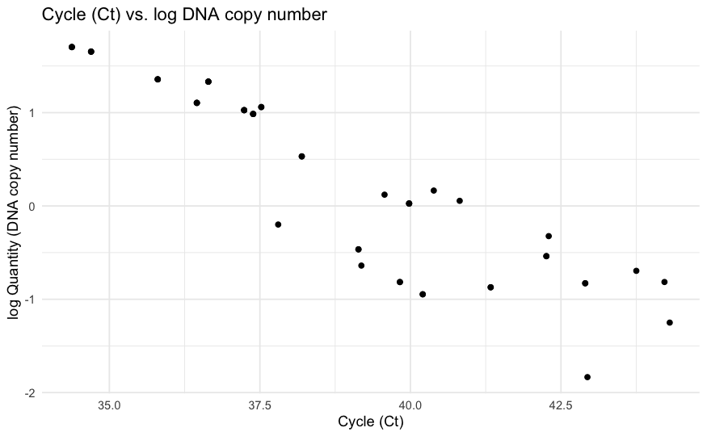

```r
data.qpcr %>%
  filter(Task != "STANDARD",
         CT != "Undetermined") %>%
  ggplot(aes(x = `Ct Mean`, y = log10(`Quantity Mean`))) +
  geom_point() +
  theme_minimal() +
  labs(title = "Cycle (Ct) vs. log DNA copy number",
       x = "Cycle (Ct)",
       y = "log Quantity (DNA copy number)")
```

The relationship drifts at higher cycle numbers - or because this is outside the detection threshold at this point.

Samples amplified on multiple plates?

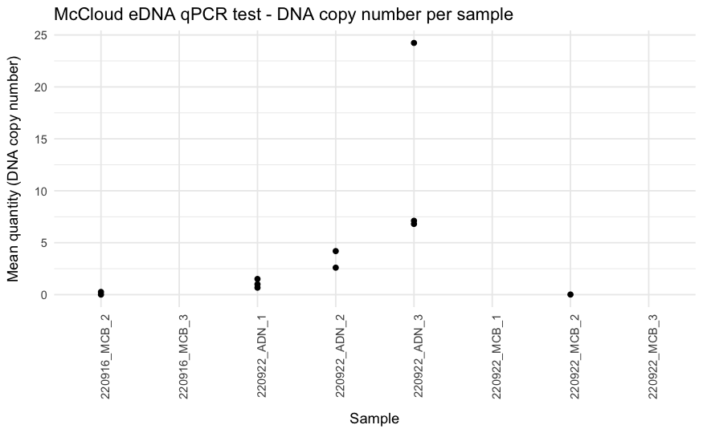

```r
sample.data <- data.qpcr %>%
   filter(Task != "STANDARD", `Sample Name` != "NTC") %>%
  group_by(`Sample Name`) %>%
  add_tally() %>%
  arrange(`Sample Name`)

# look at amplification per sample
sample.data %>%
  filter(n > 3) %>%
   ggplot(aes(x = `Sample Name`, y = Quantity)) +
  geom_point() +
  theme_minimal() +
  labs(title = "McCloud eDNA qPCR test - DNA copy number per sample",
       x = "Sample",
       y = "Mean quantity (DNA copy number)") +
  theme(
    axis.text.x = element_text(angle = 90, hjust = 0.95),
    axis.title.x = element_text(margin = margin(t = 10)),
    axis.title.y = element_text(margin = margin(r = 10)),
  )
```

```r
NA
```

Cycle number for that subset of samples?

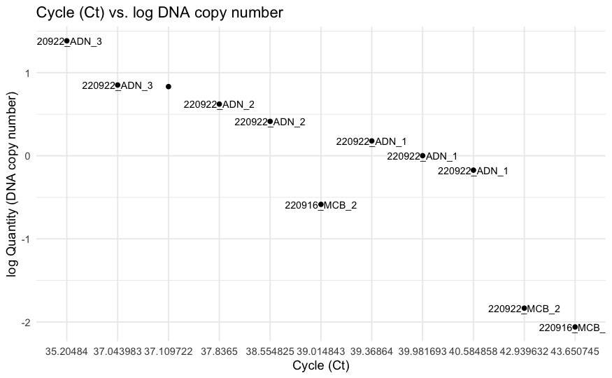

```r
sample.data %>%
  filter(n > 3,
         CT != "Undetermined") %>%
  ggplot(aes(x = CT, y = log10(Quantity))) +
  geom_point() +
  geom_text(aes(label = `Sample Name`), check_overlap = T, size = 3) +
  theme_minimal() +
  labs(title = "Cycle (Ct) vs. log DNA copy number",
       x = "Cycle (Ct)",
       y = "log Quantity (DNA copy number)")
```

```r
NA
```

Quickly look at trends in sample means over the temporal period sampled.

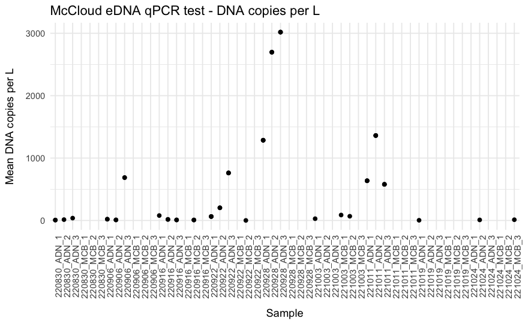

```r
sample.data %>%
 ggplot(aes(x = `Sample Name`, y = mean_copies_per_L)) +
  geom_point() +
  theme_minimal() +
  labs(title = "McCloud eDNA qPCR test - DNA copies per L",
       x = "Sample",
       y = "Mean DNA copies per L") +
  theme(
    axis.text.x = element_text(angle = 90, hjust = 0.95),
    axis.title.x = element_text(margin = margin(t = 10)),
    axis.title.y = element_text(margin = margin(r = 10)),
  )
```

```r
NA
NA
```

Make two factors for the sites: ADN and MCB

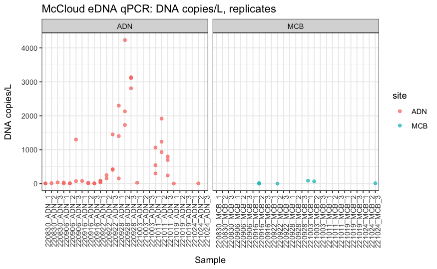

```r
# this plot does not use the mean DNA copy number quantity - so there should be multiple data points per sample replicate
sample.data %>%
  mutate(site = ifelse(str_detect(`Sample Name`, "ADN"), "ADN", "MCB")) %>%
  ggplot(aes(x = `Sample Name`, y = copies_per_L, color = site)) +
  geom_point(alpha = 0.7) +
  theme_bw() +
  facet_grid(cols = vars(site), scales = "free_x") +
  labs(title = "McCloud eDNA qPCR: DNA copies/L, replicates",
       x = "Sample",
       y = "DNA copies/L") +
  theme(
    axis.text.x = element_text(angle = 90, hjust = 0.95),
    axis.title.x = element_text(margin = margin(t = 10)),
    axis.title.y = element_text(margin = margin(r = 10)),
  )

ggsave("pdf_outputs/plates1_2_copies_L_by_replicate.pdf", height = 5, width = 8)
```

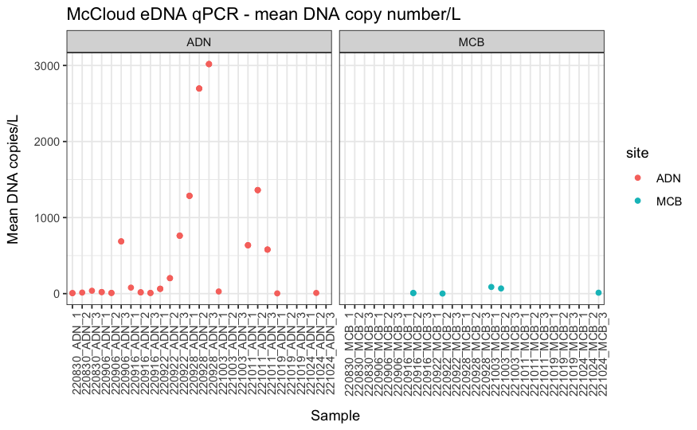

```r
sample.data %>%
  mutate(site = ifelse(str_detect(`Sample Name`, "ADN"), "ADN", "MCB")) %>%
  ggplot(aes(x = `Sample Name`, y = mean_copies_per_L, color = site)) +
  geom_point() +
  theme_bw() +
  facet_grid(cols = vars(site), scales = "free_x") +
  labs(title = "McCloud eDNA qPCR - mean DNA copy number/L",
       x = "Sample",
       y = "Mean DNA copies/L") +
  theme(
    axis.text.x = element_text(angle = 90, hjust = 0.95),
    axis.title.x = element_text(margin = margin(t = 10)),
    axis.title.y = element_text(margin = margin(r = 10)),
  )
```

## Add metadata

```r
meta <- read_xlsx("../data/WRCSMcCloud22_eDNAMetadata_CJS_dsb.xlsx", sheet = "meta_simple")

meta
```

| Sample ID | Date Collected | Extraction volume (uL) | ND Quant (ng/uL) | A260/280 | A260/230 |
| --- | --- | --- | --- | --- | --- |
| 220830_ADN_1 | 2022-08-30 | 120 | 32.27 | 1.59 | 0.58 |
| 220830_ADN_2 | 2022-08-30 | 120 | 10.26 | 1.92 | 0.30 |
| 220830_ADN_3 | 2022-08-30 | 120 | 10.32 | 1.77 | 0.36 |
| 220830_MCB_1 | 2022-08-30 | 120 | 111.31 | 1.47 | 0.71 |
| 220830_MCB_2 | 2022-08-30 | 120 | 98.33 | 1.47 | 0.69 |
| 220830_MCB_3 | 2022-08-30 | 120 | 15.92 | 1.78 | 0.41 |
| 220906_ADN_1 | 2022-09-06 | 120 | 30.53 | 1.62 | 0.70 |
| 220906_ADN_2 | 2022-09-06 | 120 | 12.60 | 1.99 | 0.51 |
| 220906_ADN_3 | 2022-09-06 | 120 | 34.10 | 1.86 | 0.98 |
| 220906_MCB_1 | 2022-09-06 | 120 | 22.34 | 1.62 | 0.54 |

[output cut: 44 more lines]

combine qPCR and metadata

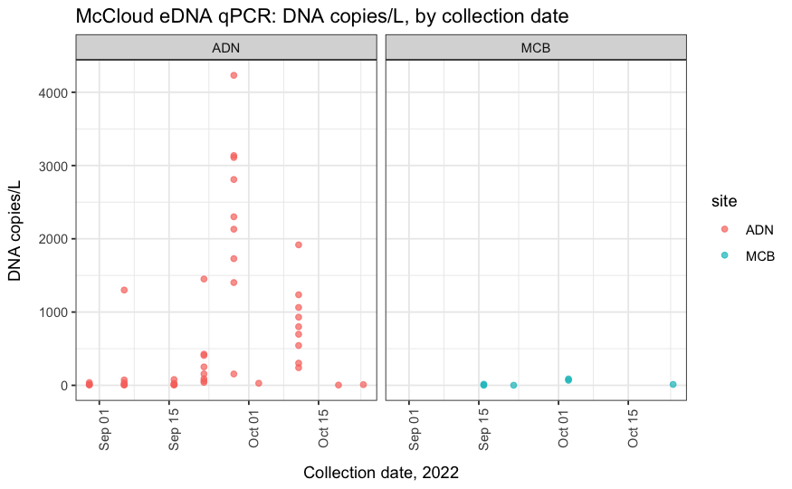

```r
merged.df <- sample.data %>%
  left_join(., meta, by = c("Sample Name" = "Sample ID")) %>%
  mutate(site = ifelse(str_detect(`Sample Name`, "ADN"), "ADN", "MCB"))


# plot with that info
merged.df %>%
  ggplot(aes(x = `Date Collected`, y = copies_per_L, color = site)) +
  geom_point(alpha = 0.7) +
  theme_bw() +
  facet_grid(cols = vars(site), scales = "free_x") +
  labs(title = "McCloud eDNA qPCR: DNA copies/L, by collection date",
       x = "Collection date, 2022",
       y = "DNA copies/L") +
  theme(
    axis.text.x = element_text(angle = 90, hjust = 0.95),
    axis.title.x = element_text(margin = margin(t = 10)),
    axis.title.y = element_text(margin = margin(r = 10)),
  )

ggsave("pdf_outputs/plates1_2_copies_L_by_date.pdf", height = 5, width = 8)
```

### Displaying replicates with zeros

Rachel was interested in seeing how many replicates for a given sample detected Chinook vs. those that didn’t.

It seems like a heatmap might be a good way to capture this info.

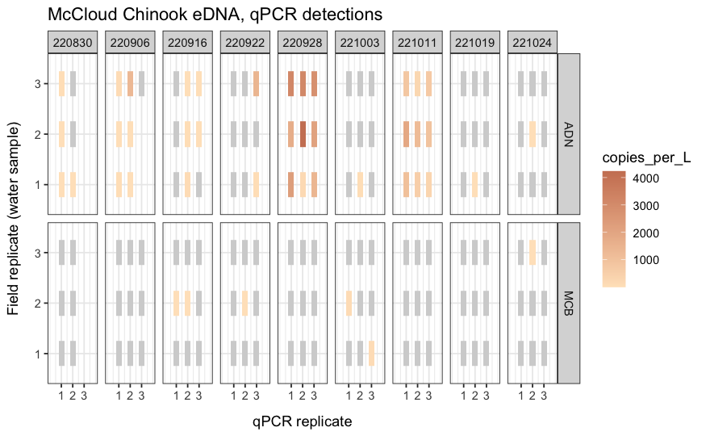

```r
merged.df %>%
  separate(`Sample Name`, into = c("collection_date", "site", "field_replicate"), remove = F) %>%
  group_by(`Sample Name`) %>%
  mutate(pcr_replicate = row_number()) %>%
  # imagine faceting by site
  ggplot(aes(x = pcr_replicate, y = field_replicate, fill = copies_per_L)) +
    geom_tile(aes(width=0.5, height=0.5)) +
  theme_bw() +
  facet_grid(rows = vars(site), cols = vars(collection_date), scales = "free") +
  labs(title = "McCloud Chinook eDNA, qPCR detections",
       x = "qPCR replicate",
       y = "Field replicate (water sample)") +
  theme(
    axis.title.x = element_text(margin = margin(t = 10)),
    axis.title.y = element_text(margin = margin(r = 10))
  ) +
  scale_x_continuous(breaks = c(1,2,3), limits = c(0,4)) +
  scale_fill_continuous(low="bisque", high="lightsalmon3",
                       guide="colorbar",na.value="lightgray")


ggsave("pdf_outputs/McCloud_Chinook_qPCR_detections_tile.pdf", width = 7, height = 3)
```

I think that looks pretty good.